# Risk Factor Analysis

## Outcome Variable

**Outcome Variable:** wasted

## Predictor Variables

**Intervention Variable:** perdiar24

**Adjustment Set:**

- arm
- sex
- meducyrs
- feducyrs
- hhwealth_quart
- hfoodsec
- vagbrth
- hdlvry
- W_birthwt
- W_birthlen
- single
- W_nrooms
- month
- brthmon
- impfloor
- impsan
- safeh20
- delta_meducyrs
- delta_feducyrs
- delta_hhwealth_quart
- delta_hfoodsec
- delta_vagbrth
- delta_hdlvry
- delta_W_birthwt
- delta_W_birthlen
- delta_single
- delta_W_nrooms
- delta_month
- delta_brthmon
- delta_impfloor
- delta_impsan
- delta_safeh20

## Stratifying Variables

The analysis was stratified on these variable(s):

- agecat
- studyid
- country

## Data Summary

| agecat | studyid | country | perdiar24 | wasted | n_cell | n |
| --- | --- | --- | --- | --- | --- | --- |
| Birth | ki0047075b-MAL-ED | BANGLADESH | 0% | 0 | 13 | 215 |
| Birth | ki0047075b-MAL-ED | BANGLADESH | 0% | 1 | 1 | 215 |
| Birth | ki0047075b-MAL-ED | BANGLADESH | (0%, 5%] | 0 | 101 | 215 |
| Birth | ki0047075b-MAL-ED | BANGLADESH | (0%, 5%] | 1 | 26 | 215 |
| Birth | ki0047075b-MAL-ED | BANGLADESH | >5% | 0 | 65 | 215 |
| Birth | ki0047075b-MAL-ED | BANGLADESH | >5% | 1 | 9 | 215 |
| Birth | ki0047075b-MAL-ED | BRAZIL | 0% | 0 | 34 | 62 |
| Birth | ki0047075b-MAL-ED | BRAZIL | 0% | 1 | 0 | 62 |
| Birth | ki0047075b-MAL-ED | BRAZIL | (0%, 5%] | 0 | 24 | 62 |
| Birth | ki0047075b-MAL-ED | BRAZIL | (0%, 5%] | 1 | 2 | 62 |
| Birth | ki0047075b-MAL-ED | BRAZIL | >5% | 0 | 2 | 62 |
| Birth | ki0047075b-MAL-ED | BRAZIL | >5% | 1 | 0 | 62 |
| Birth | ki0047075b-MAL-ED | INDIA | 0% | 0 | 5 | 45 |
| Birth | ki0047075b-MAL-ED | INDIA | 0% | 1 | 0 | 45 |
| Birth | ki0047075b-MAL-ED | INDIA | (0%, 5%] | 0 | 28 | 45 |
| Birth | ki0047075b-MAL-ED | INDIA | (0%, 5%] | 1 | 3 | 45 |
| Birth | ki0047075b-MAL-ED | INDIA | >5% | 0 | 7 | 45 |
| Birth | ki0047075b-MAL-ED | INDIA | >5% | 1 | 2 | 45 |
| Birth | ki0047075b-MAL-ED | NEPAL | 0% | 0 | 2 | 26 |
| Birth | ki0047075b-MAL-ED | NEPAL | 0% | 1 | 0 | 26 |
| Birth | ki0047075b-MAL-ED | NEPAL | (0%, 5%] | 0 | 18 | 26 |
| Birth | ki0047075b-MAL-ED | NEPAL | (0%, 5%] | 1 | 1 | 26 |
| Birth | ki0047075b-MAL-ED | NEPAL | >5% | 0 | 4 | 26 |
| Birth | ki0047075b-MAL-ED | NEPAL | >5% | 1 | 1 | 26 |
| Birth | ki0047075b-MAL-ED | PERU | 0% | 0 | 21 | 228 |
| Birth | ki0047075b-MAL-ED | PERU | 0% | 1 | 0 | 228 |
| Birth | ki0047075b-MAL-ED | PERU | (0%, 5%] | 0 | 87 | 228 |
| Birth | ki0047075b-MAL-ED | PERU | (0%, 5%] | 1 | 0 | 228 |
| Birth | ki0047075b-MAL-ED | PERU | >5% | 0 | 115 | 228 |
| Birth | ki0047075b-MAL-ED | PERU | >5% | 1 | 5 | 228 |

[output cut: 234 more lines]

The following strata were considered:

- agecat: 24 months, studyid: ki0047075b-MAL-ED, country: BANGLADESH
- agecat: 24 months, studyid: ki0047075b-MAL-ED, country: BRAZIL
- agecat: 24 months, studyid: ki0047075b-MAL-ED, country: INDIA
- agecat: 24 months, studyid: ki0047075b-MAL-ED, country: NEPAL
- agecat: 24 months, studyid: ki0047075b-MAL-ED, country: PERU
- agecat: 24 months, studyid: ki0047075b-MAL-ED, country: SOUTH AFRICA
- agecat: 24 months, studyid: ki0047075b-MAL-ED, country: TANZANIA, UNITED REPUBLIC OF
- agecat: 24 months, studyid: ki1000109-EE, country: PAKISTAN
- agecat: 24 months, studyid: ki1017093-NIH-Birth, country: BANGLADESH
- agecat: 24 months, studyid: ki1017093b-PROVIDE, country: BANGLADESH
- agecat: 24 months, studyid: ki1017093c-NIH-Crypto, country: BANGLADESH
- agecat: 24 months, studyid: ki1114097-CMIN, country: BANGLADESH
- agecat: 24 months, studyid: ki1114097-CONTENT, country: PERU
- agecat: 24 months, studyid: kiGH5241-JiVitA-4, country: BANGLADESH
- agecat: 6 months, studyid: ki0047075b-MAL-ED, country: BANGLADESH
- agecat: 6 months, studyid: ki0047075b-MAL-ED, country: BRAZIL
- agecat: 6 months, studyid: ki0047075b-MAL-ED, country: INDIA
- agecat: 6 months, studyid: ki0047075b-MAL-ED, country: NEPAL
- agecat: 6 months, studyid: ki0047075b-MAL-ED, country: PERU
- agecat: 6 months, studyid: ki0047075b-MAL-ED, country: SOUTH AFRICA
- agecat: 6 months, studyid: ki0047075b-MAL-ED, country: TANZANIA, UNITED REPUBLIC OF
- agecat: 6 months, studyid: ki1000109-EE, country: PAKISTAN
- agecat: 6 months, studyid: ki1000304b-SAS-FoodSuppl, country: INDIA
- agecat: 6 months, studyid: ki1017093-NIH-Birth, country: BANGLADESH
- agecat: 6 months, studyid: ki1017093b-PROVIDE, country: BANGLADESH
- agecat: 6 months, studyid: ki1017093c-NIH-Crypto, country: BANGLADESH
- agecat: 6 months, studyid: ki1112895-Guatemala BSC, country: GUATEMALA
- agecat: 6 months, studyid: ki1114097-CMIN, country: BANGLADESH
- agecat: 6 months, studyid: ki1114097-CONTENT, country: PERU
- agecat: 6 months, studyid: kiGH5241-JiVitA-4, country: BANGLADESH
- agecat: Birth, studyid: ki0047075b-MAL-ED, country: BANGLADESH
- agecat: Birth, studyid: ki0047075b-MAL-ED, country: BRAZIL
- agecat: Birth, studyid: ki0047075b-MAL-ED, country: INDIA
- agecat: Birth, studyid: ki0047075b-MAL-ED, country: NEPAL
- agecat: Birth, studyid: ki0047075b-MAL-ED, country: PERU
- agecat: Birth, studyid: ki0047075b-MAL-ED, country: SOUTH AFRICA
- agecat: Birth, studyid: ki0047075b-MAL-ED, country: TANZANIA, UNITED REPUBLIC OF
- agecat: Birth, studyid: ki1000109-EE, country: PAKISTAN
- agecat: Birth, studyid: ki1017093-NIH-Birth, country: BANGLADESH
- agecat: Birth, studyid: ki1017093b-PROVIDE, country: BANGLADESH
- agecat: Birth, studyid: ki1017093c-NIH-Crypto, country: BANGLADESH
- agecat: Birth, studyid: ki1114097-CMIN, country: BANGLADESH
- agecat: Birth, studyid: ki1114097-CONTENT, country: PERU
- agecat: Birth, studyid: kiGH5241-JiVitA-4, country: BANGLADESH

### Dropped Strata

Some strata were dropped due to rare outcomes:

- agecat: Birth, studyid: ki0047075b-MAL-ED, country: BANGLADESH
- agecat: Birth, studyid: ki0047075b-MAL-ED, country: BRAZIL
- agecat: Birth, studyid: ki0047075b-MAL-ED, country: INDIA
- agecat: Birth, studyid: ki0047075b-MAL-ED, country: NEPAL
- agecat: Birth, studyid: ki0047075b-MAL-ED, country: PERU
- agecat: Birth, studyid: ki0047075b-MAL-ED, country: SOUTH AFRICA
- agecat: Birth, studyid: ki0047075b-MAL-ED, country: TANZANIA, UNITED REPUBLIC OF
- agecat: Birth, studyid: ki1000109-EE, country: PAKISTAN
- agecat: Birth, studyid: ki1114097-CMIN, country: BANGLADESH
- agecat: Birth, studyid: ki1114097-CONTENT, country: PERU
- agecat: 6 months, studyid: ki0047075b-MAL-ED, country: BANGLADESH
- agecat: 6 months, studyid: ki0047075b-MAL-ED, country: BRAZIL
- agecat: 6 months, studyid: ki0047075b-MAL-ED, country: INDIA
- agecat: 6 months, studyid: ki0047075b-MAL-ED, country: NEPAL
- agecat: 6 months, studyid: ki0047075b-MAL-ED, country: PERU
- agecat: 6 months, studyid: ki0047075b-MAL-ED, country: SOUTH AFRICA
- agecat: 6 months, studyid: ki0047075b-MAL-ED, country: TANZANIA, UNITED REPUBLIC OF
- agecat: 6 months, studyid: ki1000109-EE, country: PAKISTAN
- agecat: 6 months, studyid: ki1017093-NIH-Birth, country: BANGLADESH
- agecat: 6 months, studyid: ki1017093b-PROVIDE, country: BANGLADESH
- agecat: 6 months, studyid: ki1017093c-NIH-Crypto, country: BANGLADESH
- agecat: 6 months, studyid: ki1112895-Guatemala BSC, country: GUATEMALA
- agecat: 6 months, studyid: ki1114097-CMIN, country: BANGLADESH
- agecat: 6 months, studyid: ki1114097-CONTENT, country: PERU
- agecat: 24 months, studyid: ki0047075b-MAL-ED, country: BANGLADESH
- agecat: 24 months, studyid: ki0047075b-MAL-ED, country: BRAZIL
- agecat: 24 months, studyid: ki0047075b-MAL-ED, country: INDIA
- agecat: 24 months, studyid: ki0047075b-MAL-ED, country: NEPAL
- agecat: 24 months, studyid: ki0047075b-MAL-ED, country: PERU
- agecat: 24 months, studyid: ki0047075b-MAL-ED, country: SOUTH AFRICA
- agecat: 24 months, studyid: ki0047075b-MAL-ED, country: TANZANIA, UNITED REPUBLIC OF
- agecat: 24 months, studyid: ki1000109-EE, country: PAKISTAN
- agecat: 24 months, studyid: ki1017093-NIH-Birth, country: BANGLADESH
- agecat: 24 months, studyid: ki1017093b-PROVIDE, country: BANGLADESH
- agecat: 24 months, studyid: ki1114097-CMIN, country: BANGLADESH
- agecat: 24 months, studyid: ki1114097-CONTENT, country: PERU

## Methods Detail

We’re interested in the causal parameters $E[Y_a]$ for all values of $a \in \mathcal{A}$. These parameters represent the mean outcome if, possibly contrary to fact, we intervened to set all units to have $A=a$. Under the randomization and positivity assumptions, these are identified by the statistical parameters $\psi_a=E_W[E_{Y|A,W}(Y|A=a,W)]$. In addition, we’re interested in the mean of $Y$, $E[Y]$ under no intervention (the observed mean). We will estimate these parameters by using SuperLearner to fit the relevant likelihood factors – $E_{Y|A,W}(Y|A=a,W)$ and $p(A=a|W)$, and then updating our likelihood fit using a joint TMLE.

For unadjusted analyses ($W=\{\}$), initial likelihoods were estimated using Lrnr_glm to estimate the simple $E(Y|A)$ and Lrnr_mean to estimate $p(A)$. For adjusted analyses, a small library containing Lrnr_glmnet, Lrnr_xgboost, and Lrnr_mean was used.

Having estimated these parameters, we will then use the delta method to estimate relative risks and attributable risks relative to a prespecified baseline level of $A$.

# Results Detail

## Results Plots

[figure not shown]

[figure not shown]

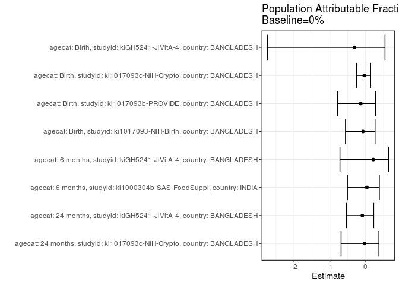

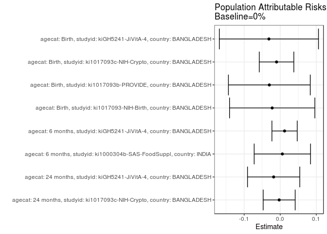

## Results Table

### Parameter: TSM

| agecat | studyid | country | intervention_level | baseline_level | estimate | ci_lower | ci_upper |
| --- | --- | --- | --- | --- | --- | --- | --- |
| Birth | ki1017093-NIH-Birth | BANGLADESH | 0% | NA | 0.3160090 | 0.1933444 | 0.4386735 |
| Birth | ki1017093-NIH-Birth | BANGLADESH | (0%, 5%] | NA | 0.2798426 | 0.2313492 | 0.3283360 |
| Birth | ki1017093-NIH-Birth | BANGLADESH | >5% | NA | 0.3228140 | 0.2578053 | 0.3878227 |
| Birth | ki1017093b-PROVIDE | BANGLADESH | 0% | NA | 0.2501292 | 0.1298995 | 0.3703589 |
| Birth | ki1017093b-PROVIDE | BANGLADESH | (0%, 5%] | NA | 0.1968431 | 0.1530372 | 0.2406490 |
| Birth | ki1017093b-PROVIDE | BANGLADESH | >5% | NA | 0.2581506 | 0.1878165 | 0.3284848 |
| Birth | ki1017093c-NIH-Crypto | BANGLADESH | 0% | NA | 0.2534958 | 0.1952744 | 0.3117172 |
| Birth | ki1017093c-NIH-Crypto | BANGLADESH | (0%, 5%] | NA | 0.2328966 | 0.1936323 | 0.2721608 |
| Birth | ki1017093c-NIH-Crypto | BANGLADESH | >5% | NA | 0.2408840 | 0.1986719 | 0.2830961 |
| Birth | kiGH5241-JiVitA-4 | BANGLADESH | 0% | NA | 0.1311475 | -0.0090976 | 0.2713927 |
| Birth | kiGH5241-JiVitA-4 | BANGLADESH | (0%, 5%] | NA | 0.0985175 | 0.0826046 | 0.1144304 |
| Birth | kiGH5241-JiVitA-4 | BANGLADESH | >5% | NA | 0.1024590 | 0.0470775 | 0.1578405 |
| 6 months | ki1000304b-SAS-FoodSuppl | INDIA | 0% | NA | 0.1756757 | 0.0888578 | 0.2624936 |
| 6 months | ki1000304b-SAS-FoodSuppl | INDIA | (0%, 5%] | NA | 0.1739130 | 0.0642348 | 0.2835912 |
| 6 months | ki1000304b-SAS-FoodSuppl | INDIA | >5% | NA | 0.1846154 | 0.1373929 | 0.2318379 |
| 6 months | kiGH5241-JiVitA-4 | BANGLADESH | 0% | NA | 0.0448718 | 0.0095437 | 0.0801999 |
| 6 months | kiGH5241-JiVitA-4 | BANGLADESH | (0%, 5%] | NA | 0.0541777 | 0.0449929 | 0.0633625 |
| 6 months | kiGH5241-JiVitA-4 | BANGLADESH | >5% | NA | 0.0820611 | 0.0486177 | 0.1155045 |
| 24 months | ki1017093c-NIH-Crypto | BANGLADESH | 0% | NA | 0.0904541 | 0.0394984 | 0.1414099 |
| 24 months | ki1017093c-NIH-Crypto | BANGLADESH | (0%, 5%] | NA | 0.0879887 | 0.0544524 | 0.1215251 |
| 24 months | ki1017093c-NIH-Crypto | BANGLADESH | >5% | NA | 0.0860966 | 0.0356044 | 0.1365887 |
| 24 months | kiGH5241-JiVitA-4 | BANGLADESH | 0% | NA | 0.2125778 | 0.1388446 | 0.2863110 |
| 24 months | kiGH5241-JiVitA-4 | BANGLADESH | (0%, 5%] | NA | 0.1935979 | 0.1796709 | 0.2075249 |
| 24 months | kiGH5241-JiVitA-4 | BANGLADESH | >5% | NA | 0.1936051 | 0.1476684 | 0.2395418 |

### Parameter: E(Y)

| agecat | studyid | country | intervention_level | baseline_level | estimate | ci_lower | ci_upper |
| --- | --- | --- | --- | --- | --- | --- | --- |
| Birth | ki1017093-NIH-Birth | BANGLADESH | NA | NA | 0.2937063 | 0.2563487 | 0.3310639 |
| Birth | ki1017093b-PROVIDE | BANGLADESH | NA | NA | 0.2199248 | 0.1846953 | 0.2551543 |
| Birth | ki1017093c-NIH-Crypto | BANGLADESH | NA | NA | 0.2432815 | 0.2116319 | 0.2749310 |
| Birth | kiGH5241-JiVitA-4 | BANGLADESH | NA | NA | 0.0997496 | 0.0843744 | 0.1151247 |
| 6 months | ki1000304b-SAS-FoodSuppl | INDIA | NA | NA | 0.1815789 | 0.1427684 | 0.2203895 |
| 6 months | kiGH5241-JiVitA-4 | BANGLADESH | NA | NA | 0.0569005 | 0.0480577 | 0.0657432 |
| 24 months | ki1017093c-NIH-Crypto | BANGLADESH | NA | NA | 0.0875486 | 0.0630907 | 0.1120065 |
| 24 months | kiGH5241-JiVitA-4 | BANGLADESH | NA | NA | 0.1942978 | 0.1810880 | 0.2075076 |

### Parameter: RR

| agecat | studyid | country | intervention_level | baseline_level | estimate | ci_lower | ci_upper |
| --- | --- | --- | --- | --- | --- | --- | --- |
| Birth | ki1017093-NIH-Birth | BANGLADESH | 0% | 0% | 1.0000000 | 1.0000000 | 1.000000 |
| Birth | ki1017093-NIH-Birth | BANGLADESH | (0%, 5%] | 0% | 0.8855526 | 0.5791106 | 1.354151 |
| Birth | ki1017093-NIH-Birth | BANGLADESH | >5% | 0% | 1.0215342 | 0.6606016 | 1.579669 |
| Birth | ki1017093b-PROVIDE | BANGLADESH | 0% | 0% | 1.0000000 | 1.0000000 | 1.000000 |
| Birth | ki1017093b-PROVIDE | BANGLADESH | (0%, 5%] | 0% | 0.7869655 | 0.4632805 | 1.336803 |
| Birth | ki1017093b-PROVIDE | BANGLADESH | >5% | 0% | 1.0320691 | 0.5938009 | 1.793811 |
| Birth | ki1017093c-NIH-Crypto | BANGLADESH | 0% | 0% | 1.0000000 | 1.0000000 | 1.000000 |
| Birth | ki1017093c-NIH-Crypto | BANGLADESH | (0%, 5%] | 0% | 0.9187392 | 0.7153215 | 1.180003 |
| Birth | ki1017093c-NIH-Crypto | BANGLADESH | >5% | 0% | 0.9502482 | 0.7363464 | 1.226286 |
| Birth | kiGH5241-JiVitA-4 | BANGLADESH | 0% | 0% | 1.0000000 | 1.0000000 | 1.000000 |
| Birth | kiGH5241-JiVitA-4 | BANGLADESH | (0%, 5%] | 0% | 0.7511956 | 0.2542327 | 2.219600 |
| Birth | kiGH5241-JiVitA-4 | BANGLADESH | >5% | 0% | 0.7812500 | 0.2381172 | 2.563241 |
| 6 months | ki1000304b-SAS-FoodSuppl | INDIA | 0% | 0% | 1.0000000 | 1.0000000 | 1.000000 |
| 6 months | ki1000304b-SAS-FoodSuppl | INDIA | (0%, 5%] | 0% | 0.9899666 | 0.4442801 | 2.205892 |
| 6 months | ki1000304b-SAS-FoodSuppl | INDIA | >5% | 0% | 1.0508876 | 0.6024010 | 1.833272 |
| 6 months | kiGH5241-JiVitA-4 | BANGLADESH | 0% | 0% | 1.0000000 | 1.0000000 | 1.000000 |
| 6 months | kiGH5241-JiVitA-4 | BANGLADESH | (0%, 5%] | 0% | 1.2073888 | 0.5378249 | 2.710525 |
| 6 months | kiGH5241-JiVitA-4 | BANGLADESH | >5% | 0% | 1.8287895 | 0.7794357 | 4.290888 |
| 24 months | ki1017093c-NIH-Crypto | BANGLADESH | 0% | 0% | 1.0000000 | 1.0000000 | 1.000000 |
| 24 months | ki1017093c-NIH-Crypto | BANGLADESH | (0%, 5%] | 0% | 0.9727442 | 0.4927210 | 1.920420 |
| 24 months | ki1017093c-NIH-Crypto | BANGLADESH | >5% | 0% | 0.9518255 | 0.4217435 | 2.148158 |
| 24 months | kiGH5241-JiVitA-4 | BANGLADESH | 0% | 0% | 1.0000000 | 1.0000000 | 1.000000 |
| 24 months | kiGH5241-JiVitA-4 | BANGLADESH | (0%, 5%] | 0% | 0.9107155 | 0.6384527 | 1.299082 |
| 24 months | kiGH5241-JiVitA-4 | BANGLADESH | >5% | 0% | 0.9107493 | 0.5984733 | 1.385967 |

### Parameter: PAR

| agecat | studyid | country | intervention_level | baseline_level | estimate | ci_lower | ci_upper |
| --- | --- | --- | --- | --- | --- | --- | --- |
| Birth | ki1017093-NIH-Birth | BANGLADESH | 0% | NA | -0.0223027 | -0.1405969 | 0.0959915 |
| Birth | ki1017093b-PROVIDE | BANGLADESH | 0% | NA | -0.0302044 | -0.1436916 | 0.0832828 |
| Birth | ki1017093c-NIH-Crypto | BANGLADESH | 0% | NA | -0.0102144 | -0.0581079 | 0.0376792 |
| Birth | kiGH5241-JiVitA-4 | BANGLADESH | 0% | NA | -0.0313980 | -0.1689018 | 0.1061059 |
| 6 months | ki1000304b-SAS-FoodSuppl | INDIA | 0% | NA | 0.0059033 | -0.0722505 | 0.0840570 |
| 6 months | kiGH5241-JiVitA-4 | BANGLADESH | 0% | NA | 0.0120287 | -0.0230586 | 0.0471160 |
| 24 months | ki1017093c-NIH-Crypto | BANGLADESH | 0% | NA | -0.0029055 | -0.0472566 | 0.0414456 |
| 24 months | kiGH5241-JiVitA-4 | BANGLADESH | 0% | NA | -0.0182800 | -0.0907728 | 0.0542127 |

### Parameter: PAF

| agecat | studyid | country | intervention_level | baseline_level | estimate | ci_lower | ci_upper |
| --- | --- | --- | --- | --- | --- | --- | --- |
| Birth | ki1017093-NIH-Birth | BANGLADESH | 0% | NA | -0.0759354 | -0.5651533 | 0.2603683 |
| Birth | ki1017093b-PROVIDE | BANGLADESH | 0% | NA | -0.1373397 | -0.7896298 | 0.2772016 |
| Birth | ki1017093c-NIH-Crypto | BANGLADESH | 0% | NA | -0.0419858 | -0.2585626 | 0.1373219 |
| Birth | kiGH5241-JiVitA-4 | BANGLADESH | 0% | NA | -0.3147678 | -2.7366393 | 0.5373880 |
| 6 months | ki1000304b-SAS-FoodSuppl | INDIA | 0% | NA | 0.0325108 | -0.5095190 | 0.3799115 |
| 6 months | kiGH5241-JiVitA-4 | BANGLADESH | 0% | NA | 0.2113986 | -0.7184872 | 0.6381165 |
| 24 months | ki1017093c-NIH-Crypto | BANGLADESH | 0% | NA | -0.0331873 | -0.6869422 | 0.3672125 |
| 24 months | kiGH5241-JiVitA-4 | BANGLADESH | 0% | NA | -0.0940825 | -0.5387381 | 0.2220791 |